# L14 - Linear Regression

## Lecture Goals

- Examine and model the relationship between two numerical variables
  - Perform simple linear regression
  - Assess model fit
  - Create predictions
- Readings
  - [R4DS](https://r4ds.had.co.nz): ch. 23.1-3
  - [ISRS](https://www.openintro.org/download.php?file=isrs1_tablet&referrer=/stat/textbook.php): ch. 5.1-2

## Variable Relationships

- Gapminder '07, life expectancy vs GPD/capita

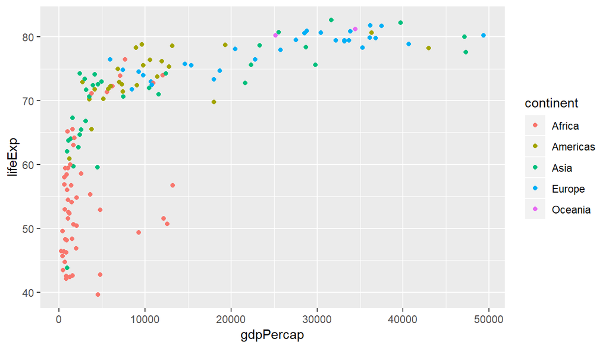

```r
gap07 %>% ggplot( aes(x = gdpPercap, y = lifeExp, col = continent)) +
  geom_point()
```

## Modeling Relationships

- Label the two variables \(X\) and \(Y\)
  - \(Y\) is *response* variable
  - \(X\) is *explanatory/predictor* variable
- Goal is to predict/affect value of \(Y\), based on knowing/manipulating value of \(X\)
- Use function \(f(\cdot)\) to model relationship
  - For each \(X\) value, function gives *average* \(Y\) value
  - Estimate \(f(\cdot)\) using data pairs \(\{(y_i,x_i)\}_{i=1}^{n} =\)

  \[= \{(y_1,x_1),\ldots,(y_n,x_n) \}\]

## Linear Relationships

- Focus on European countries

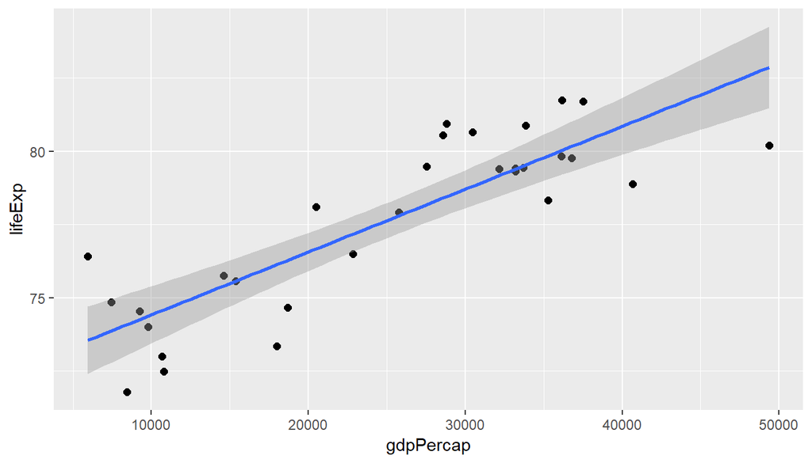

```r
gap07Europe %>% ggplot( aes(x = gdpPercap, y = lifeExp )) +
  geom_point(size = 2) + geom_smooth( method = "lm")
```

## Simple Linear Regression

- *Linear* function: \(f(x) = \alpha + \beta x\)
  - Parameters: *intercept* (\(\alpha\)) and *slope* (\(\beta\))
  - *Linear relationship*: for 1 unit increase in \(X\), "expect"" \(\beta\) units increase in \(Y\)
- Estimate parameters by *minimizing* the *mean squared error* (MSE) of the data from the line  
  \[ y_i = f(x_i) + \epsilon_i = \overbrace{ \alpha + \beta x_i}^{\textrm{fitted value}} + \overbrace{ \epsilon_i }^{\textrm{residual}}, \quad i=1,\ldots,n \\ MSE = (\epsilon_1^2 + \epsilon_2^2 + \ldots + \epsilon_n^2) / n \]

## Simple Linear Regression

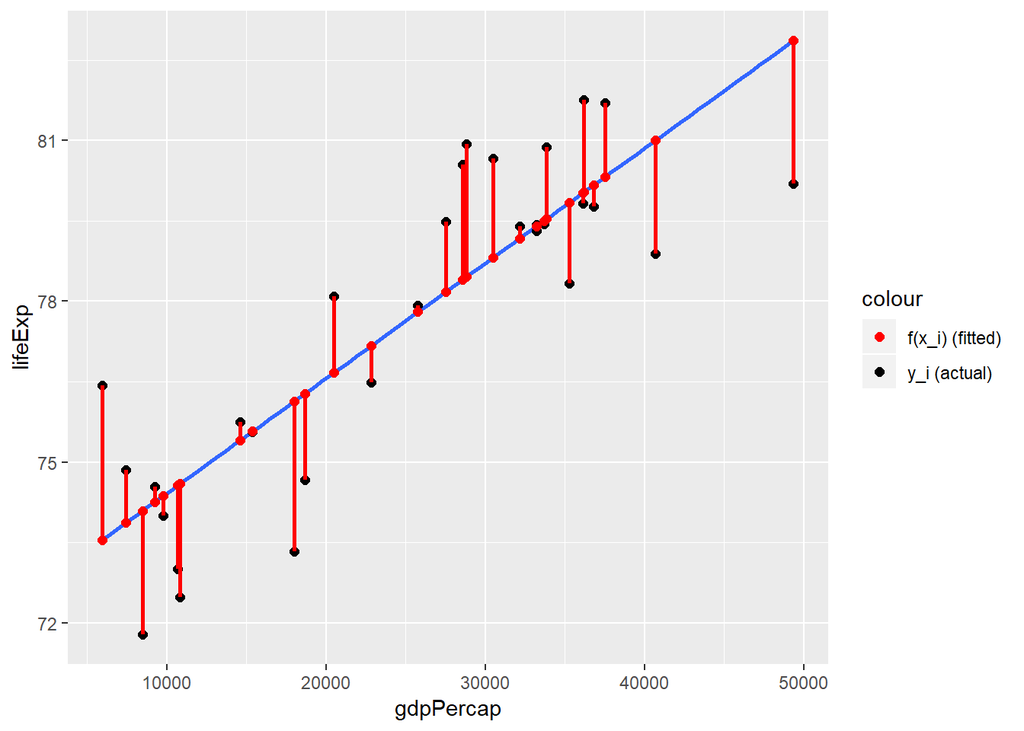

## Fitting Linear Models

- Function `lm()` fits linear model
  - Models saved as objects, passed on to other functions

```r
lm_out = gap07Europe %>% lm( lifeExp ~ gdpPercap, data = . )
summary(lm_out)
##
## Call:
## lm(formula = lifeExp ~ gdpPercap, data = .)
##
## Residuals:
##      Min       1Q   Median       3Q      Max
## -2.79839 -1.30472  0.00807  1.33443  2.87766
##
## Coefficients:
##              Estimate Std. Error t value Pr(>|t|)
## (Intercept) 7.227e+01  6.942e-01 104.113  < 2e-16 ***
## gdpPercap   2.146e-04  2.514e-05   8.537  2.8e-09 ***
## ---
## Signif. codes:  0 '***' 0.001 '**' 0.01 '*' 0.05 '.' 0.1 ' ' 1
##
## Residual standard error: 1.598 on 28 degrees of freedom
## Multiple R-squared:  0.7225, Adjusted R-squared:  0.7125
## F-statistic: 72.88 on 1 and 28 DF,  p-value: 2.795e-09
```

## Model Objects

- `broom` package converts model info into tidy data-frames
  - `tidy()` for parameters values
  - `glance()` for model statistics
  - `augment()` for fitted/residual values to original data

```r
library(broom)
tidy(lm_out)
## # A tibble: 2 x 5
##   term         estimate std.error statistic  p.value
##   <chr>           <dbl>     <dbl>     <dbl>    <dbl>
## 1 (Intercept) 72.3      0.694        104.   8.50e-38
## 2 gdpPercap    0.000215 0.0000251      8.54 2.80e- 9
augment(lm_out)
## # A tibble: 30 x 9
##    lifeExp gdpPercap .fitted .se.fit  .resid   .hat .sigma .cooksd
##      <dbl>     <dbl>   <dbl>   <dbl>   <dbl>  <dbl>  <dbl>   <dbl>
##  1    76.4     5937.    73.5   0.562  2.88   0.124    1.52 2.62e-1
##  2    79.8    36126.    80.0   0.403 -0.196  0.0637   1.63 5.47e-4
##  3    79.4    33693.    79.5   0.364 -0.0616 0.0518   1.63 4.29e-5
##  4    74.9     7446.    73.9   0.530  0.983  0.110    1.61 2.63e-2
##  5    73.0    10681.    74.6   0.464 -1.56   0.0845   1.60 4.80e-2
##  6    75.7    14619.    75.4   0.392  0.339  0.0603   1.63 1.54e-3
##  7    76.5    22833.    77.2   0.297 -0.686  0.0346   1.62 3.42e-3
##  8    78.3    35278.    79.8   0.389 -1.51   0.0592   1.60 2.99e-2
##  9    79.3    33207.    79.4   0.357 -0.0854 0.0498   1.63 7.88e-5
## 10    80.7    30470.    78.8   0.322  1.85   0.0406   1.59 2.94e-2
## # ... with 20 more rows, and 1 more variable: .std.resid <dbl>
```

## Predictions

- Models used to make *predictions* based on *new X data*
  - Use `add_predictions()` in `modelr` package

```r
library(modelr)
gap_pred = tibble( gdpPercap = (1:4)*10000 ) %>%
  add_predictions( lm_out , var = "lifeExp")
gap_pred
## # A tibble: 4 x 2
##   gdpPercap lifeExp
##       <dbl>   <dbl>
## 1     10000    74.4
## 2     20000    76.6
## 3     30000    78.7
## 4     40000    80.9
```

## Predictions

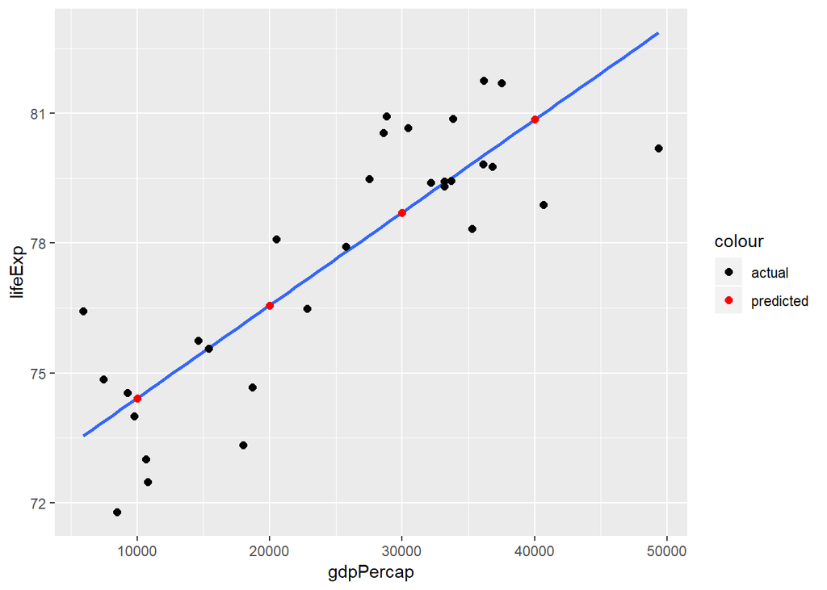

## Prediction Error

- Predictions are points along \(f(\cdot)\)
  - Represent **average** \(Y\) for given level of \(X\)
- Actual \(Y\) values are scattered around \(f(X)\)
  - Variability around prediction measured by *residual standard error* \[ \sigma_{res} = \sqrt{MSE} \]
  - Expect around 95% of data within two standard deviations of prediction (\(f(x_i) \pm 2 \times \sigma_{res}\))

## Predictions

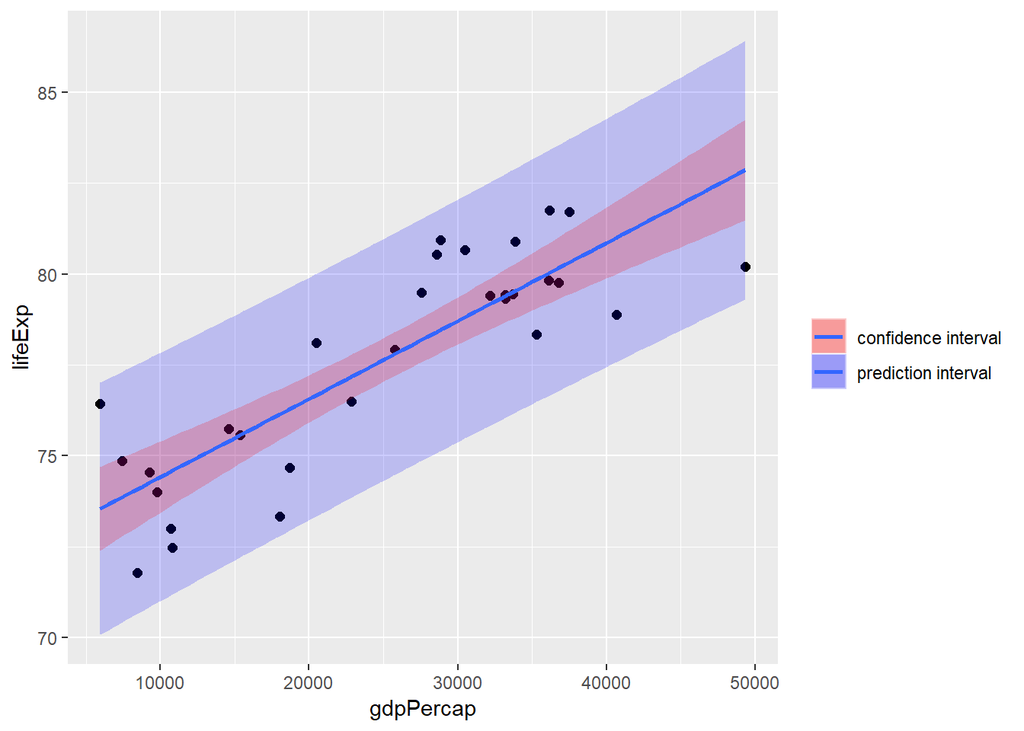

## Extrapolation

- Predictions outside observed range of \(X\) are *not* reliable

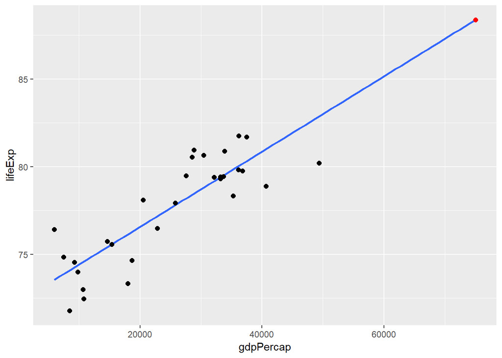

## Measuring Fit

- \(R^2\) measures *how well* model fits data (ratio 0-100%)

\[ R^2=1 - \frac{MSE(\textrm{model})}{MSE(\textrm{no rel.})} \]

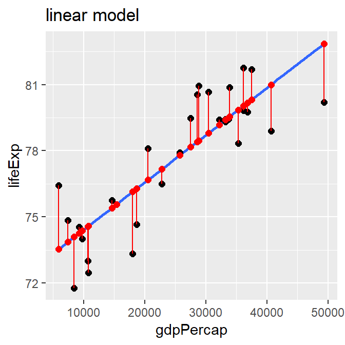

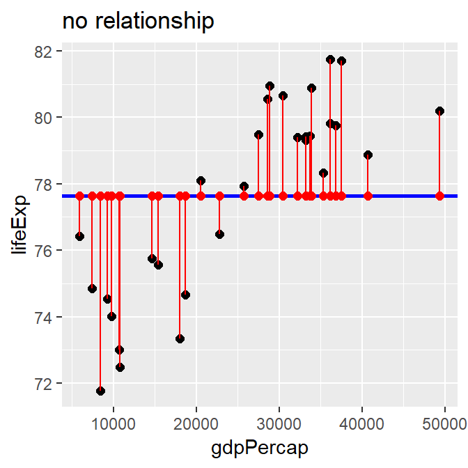

## Correlation

- *Correlation coefficient* (\(\rho\)) is *directional* measure of *linear* association \[\rho = \pm \sqrt{R^2}\]

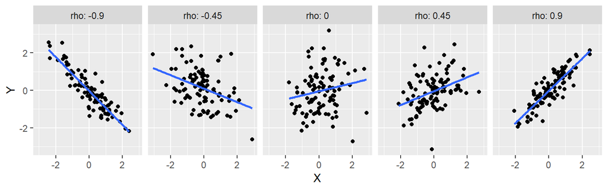

## Regression Cautions

- Can fit linear regression model to *any* data
  - Should only use it when appropriate
- Always check model fit for potential problems
  - *Non-linearity, outliers, influential points*
- E.g. [Anscombe's quartet](https://en.wikipedia.org/wiki/Anscombe%27s_quartet): models w/ identical \(\alpha, \beta, R^2\)

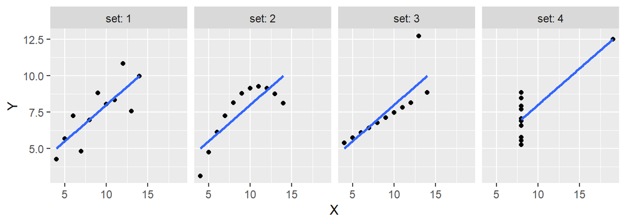

## Transformations

- Fit can be better on *transformed* variables (X and/or Y)
  - Use *invertible* transformations (log/exp, root/power)
  - Adjust predictions accordingly

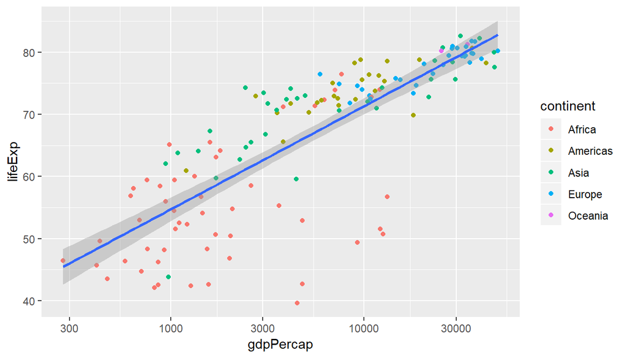